# Profit Projection for Timeless Transport Models

2025-03-18

# Summary

Timeless Transport Models wants to know the expected profit going into the second half of 2005. Using production and sales data to:

1. Estimate the unit production costs using linear regression.
2. Find the average profit per unit for each product line.
3. Forecast of monthly sales from June 2005 to December 2005 using time series modeling.
4. Compute expected profit calculation to find the total profit.

Findings:

TImeless Transport Models is expected to make $1,113,052.04 in profit from June 2005 to December 2005.

# Classic Cars Sales Forecast

```r
library(tidyverse)
sales <- read.csv("data/sales_data_sample.csv")

# Add an order_month column to sales that is the month the order took place.
sales$order_month = floor_date(as.Date(sales$ORDERDATE, "%m/%d/%Y"), unit="month")

# Filter the sales data for Classic Cars product line
cc_sales <- sales[sales$PRODUCTLINE == "Classic Cars",]

# Summarize the total quantity ordered for each month
cc_monthly_sales <- cc_sales %>%
  group_by(order_month) %>%
  summarise(qty = sum(QUANTITYORDERED))

# Make the time series object
cc_ts <- ts(cc_monthly_sales$qty, start=c(2003, 1), frequency=12)
```

```r
library(forecast)
```

```r
#Seasonal Naive method to forecast monthly sales
# cc_forecast <- forecast(snaive(cc_ts), h = 7)
# print(cc_forecast)
# autoplot(cc_forecast)

snaive(cc_ts, 7)
```

```
##          Point Forecast     Lo 80   Hi 80     Lo 95    Hi 95
## Jun 2005            742  -15.5404 1499.54 -416.5581 1900.558
## Jul 2005           1263  505.4596 2020.54  104.4419 2421.558
## Aug 2005           1885 1127.4596 2642.54  726.4419 3043.558
## Sep 2005            799   41.4596 1556.54 -359.5581 1957.558
## Oct 2005           1786 1028.4596 2543.54  627.4419 2944.558
## Nov 2005           3669 2911.4596 4426.54 2510.4419 4827.558
## Dec 2005           1006  248.4596 1763.54 -152.5581 2164.558
```

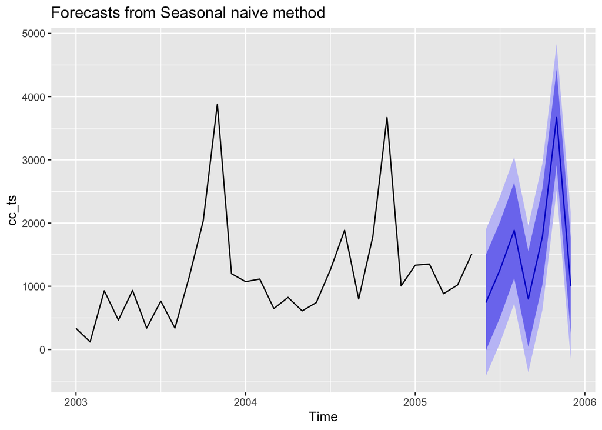

```r
autoplot(snaive(cc_ts, 7))
```

# Ships Sales Forecast

```r
# Filter the sales data for the Ships product line
ships_sales <- sales[sales$PRODUCTLINE == "Ships",]

# Summarize the total quantity ordered for each month
ships_monthly_sales <- ships_sales %>%
  group_by(order_month) %>%
  summarise(qty = sum(QUANTITYORDERED))

# Make the time series object
ships_ts <- ts(ships_monthly_sales$qty, start=c(2003, 1), frequency=12)
```

```r
#Seasonal Naive method to forecast monthly sales
snaive(ships_ts, 13)
```

```
##          Point Forecast      Lo 80     Hi 80      Lo 95     Hi 95
## Dec 2004            294  -55.71205  643.7120 -240.83842  828.8384
## Jan 2005            267  -82.71205  616.7120 -267.83842  801.8384
## Feb 2005            311  -38.71205  660.7120 -223.83842  845.8384
## Mar 2005            286  -63.71205  635.7120 -248.83842  820.8384
## Apr 2005            529  179.28795  878.7120   -5.83842 1063.8384
## May 2005            747  397.28795 1096.7120  212.16158 1281.8384
## Jun 2005            303  -46.71205  652.7120 -231.83842  837.8384
## Jul 2005            320  -29.71205  669.7120 -214.83842  854.8384
## Aug 2005            102 -247.71205  451.7120 -432.83842  636.8384
## Sep 2005            545  195.28795  894.7120   10.16158 1079.8384
## Oct 2005             76 -273.71205  425.7120 -458.83842  610.8384
## Nov 2005            303  -46.71205  652.7120 -231.83842  837.8384
## Dec 2005            294 -200.56752  788.5675 -462.37575 1050.3757
```

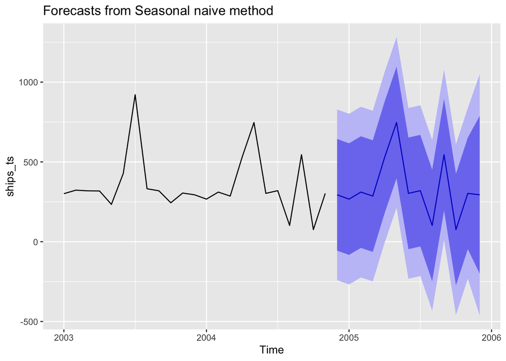

```r
autoplot(snaive(ships_ts, 13))
```

# Motorcycles Sales Forecast

```r
# Filter the sales data for the Motorcycles product line
motorcycles_sales <- sales[sales$PRODUCTLINE == "Motorcycles",]

# Summarize the total quantity ordered for each month
motorcycles_monthly_sales <- motorcycles_sales %>%
  group_by(order_month) %>%
  summarise(qty = sum(QUANTITYORDERED))

# Make the time series object
motorcycles_ts <- ts(motorcycles_monthly_sales$qty, start=c(2003, 1), frequency=12)
```

```r
#Seasonal Naive method to forecast monthly sales
snaive(motorcycles_ts, 9)
```

```
##          Point Forecast      Lo 80     Hi 80      Lo 95     Hi 95
## Apr 2005            493   37.06569  948.9343 -204.29136 1190.2914
## May 2005            214 -241.93431  669.9343 -483.29136  911.2914
## Jun 2005            675  219.06569 1130.9343  -22.29136 1372.2914
## Jul 2005            430  -25.93431  885.9343 -267.29136 1127.2914
## Aug 2005            427  -28.93431  882.9343 -270.29136 1124.2914
## Sep 2005           1403  947.06569 1858.9343  705.70864 2100.2914
## Oct 2005            268 -187.93431  723.9343 -429.29136  965.2914
## Nov 2005            377  -78.93431  832.9343 -320.29136 1074.2914
## Dec 2005            429  -26.93431  884.9343 -268.29136 1126.2914
```

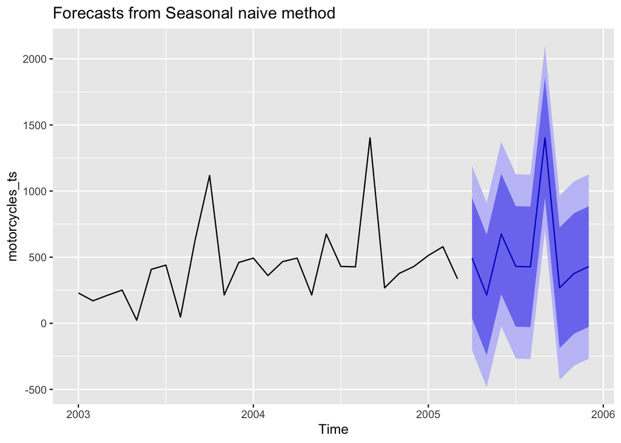

```r
autoplot(snaive(motorcycles_ts, 9))
```

# Trucks and Buses Sales Forecast

```r
# Filter the sales data for the Trucks and Buses product line
tb_sales <- sales[sales$PRODUCTLINE == "Trucks and Buses",]

# Summarize the total quantity ordered for each month
tb_monthly_sales <- tb_sales %>%
  group_by(order_month) %>%
  summarise(qty = sum(QUANTITYORDERED))

# Make the time series object
tb_ts <- ts(tb_monthly_sales$qty, start=c(2003, 1), frequency=12)
```

```r
#Seasonal Naive method to forecast monthly sales
snaive(tb_ts, 10)
```

```
##          Point Forecast      Lo 80     Hi 80      Lo 95     Hi 95
## Mar 2005            353 -67.333703  773.3337 -289.84492  995.8449
## Apr 2005            414  -6.333703  834.3337 -228.84492 1056.8449
## May 2005            380 -40.333703  800.3337 -262.84492 1022.8449
## Jun 2005            351 -69.333703  771.3337 -291.84492  993.8449
## Jul 2005            415  -5.333703  835.3337 -227.84492 1057.8449
## Aug 2005            750 329.666297 1170.3337  107.15508 1392.8449
## Sep 2005           1052 631.666297 1472.3337  409.15508 1694.8449
## Oct 2005            569 148.666297  989.3337  -73.84492 1211.8449
## Nov 2005            337 -83.333703  757.3337 -305.84492  979.8449
## Dec 2005            356 -64.333703  776.3337 -286.84492  998.8449
```

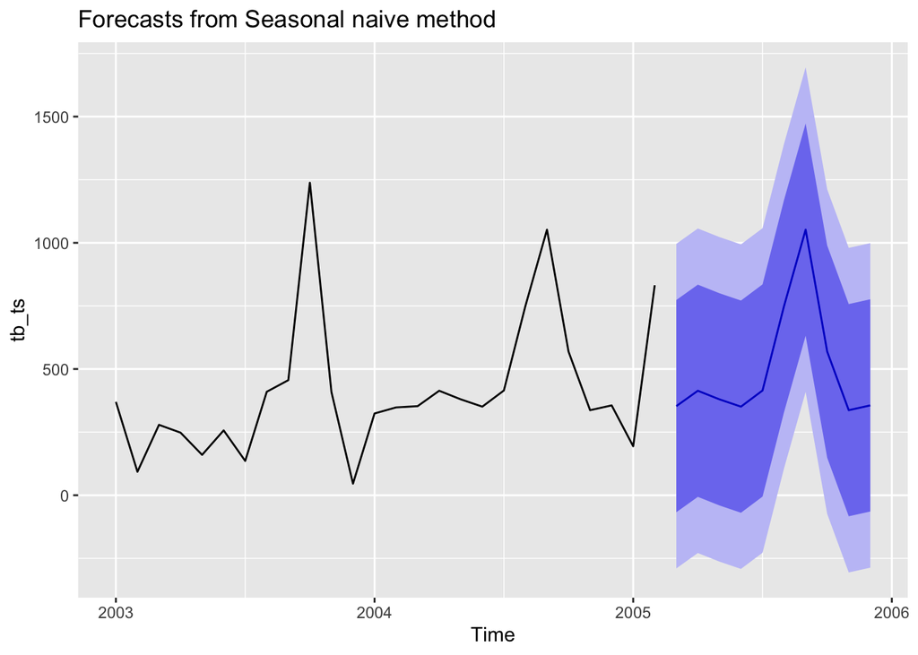

```r
autoplot(snaive(tb_ts, 10))
```

# Planes Sales Forecast

```r
# Filter the sales data for the Planes product line
planes_sales <- sales[sales$PRODUCTLINE == "Planes",]

# Summarize the total quantity ordered for each month
planes_monthly_sales <- planes_sales %>%
  group_by(order_month) %>%
  summarise(qty = sum(QUANTITYORDERED))

# Make the time series object
planes_ts <- ts(planes_monthly_sales$qty, start=c(2003, 1), frequency=12)
```

```r
#Seasonal Naive method to forecast monthly sales
snaive(planes_ts, 13)
```

```
##          Point Forecast      Lo 80     Hi 80      Lo 95     Hi 95
## Dec 2004            415  100.27631  729.7237  -66.32835  896.3284
## Jan 2005            434  119.27631  748.7237  -47.32835  915.3284
## Feb 2005            384   69.27631  698.7237  -97.32835  865.3284
## Mar 2005            360   45.27631  674.7237 -121.32835  841.3284
## Apr 2005            390   75.27631  704.7237  -91.32835  871.3284
## May 2005           1325 1010.27631 1639.7237  843.67165 1806.3284
## Jun 2005            681  366.27631  995.7237  199.67165 1162.3284
## Jul 2005            175 -139.72369  489.7237 -306.32835  656.3284
## Aug 2005            270  -44.72369  584.7237 -211.32835  751.3284
## Sep 2005            883  568.27631 1197.7237  401.67165 1364.3284
## Oct 2005            496  181.27631  810.7237   14.67165  977.3284
## Nov 2005            383   68.27631  697.7237  -98.32835  864.3284
## Dec 2005            415  -30.08652  860.0865 -265.70109 1095.7011
```

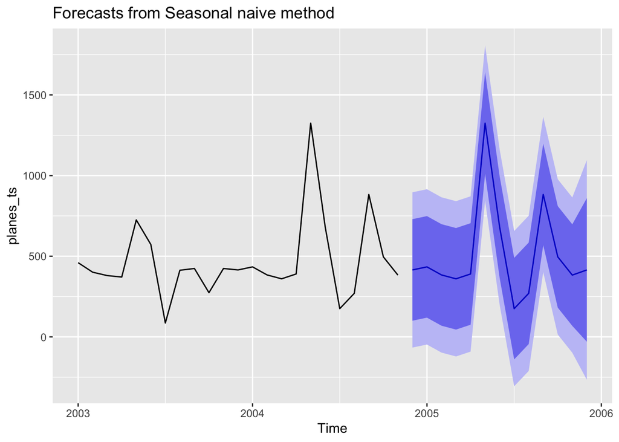

```r
autoplot(snaive(planes_ts, 13))
```

# Vintage Cars Sales Forecast

```r
# Filter the sales data for the Vintage Cars product line
vc_sales <- sales[sales$PRODUCTLINE == "Vintage Cars",]

# Summarize the total quantity ordered for each month
vc_monthly_sales <- vc_sales %>%
  group_by(order_month) %>%
  summarise(qty = sum(QUANTITYORDERED))

# Make the time series object
vc_ts <- ts(vc_monthly_sales$qty, start=c(2003, 1), frequency=12)
```

```r
#Seasonal Naive method to forecast monthly sales
snaive(vc_ts, 7)
```

```
##          Point Forecast      Lo 80     Hi 80     Lo 95    Hi 95
## Jun 2005            613  229.50584  996.4942   26.4963 1199.504
## Jul 2005            481   97.50584  864.4942 -105.5037 1067.504
## Aug 2005            849  465.50584 1232.4942  262.4963 1435.504
## Sep 2005            793  409.50584 1176.4942  206.4963 1379.504
## Oct 2005           1385 1001.50584 1768.4942  798.4963 1971.504
## Nov 2005           2305 1921.50584 2688.4942 1718.4963 2891.504
## Dec 2005            818  434.50584 1201.4942  231.4963 1404.504
```

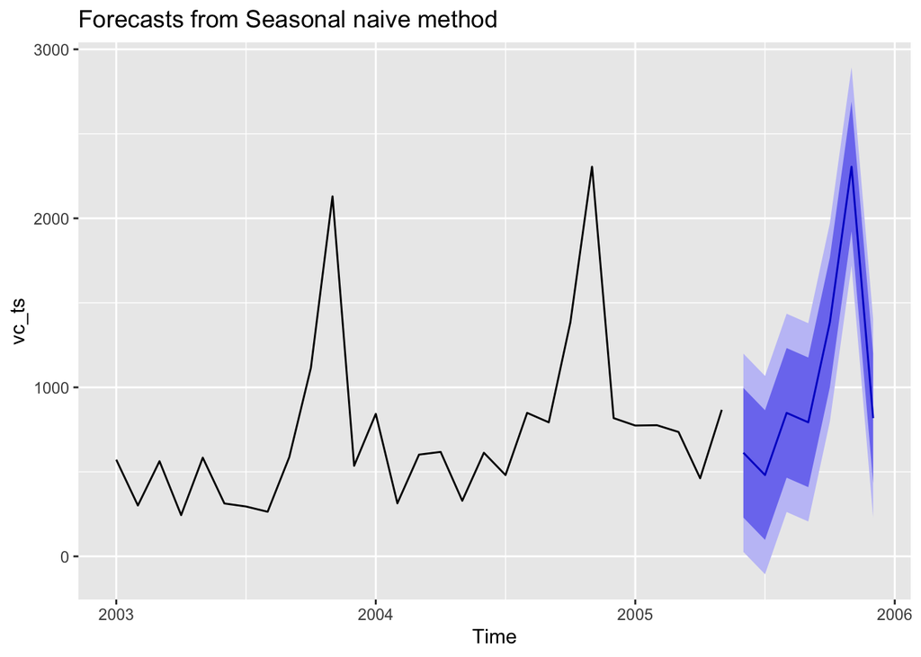

```r
autoplot(snaive(vc_ts, 7))
```

# Average Profit For Each Product Line

Classic.Cars: 113.002 - 78.1465 = $34.8555

Ships: 83.02 - 15.3710 = $67.649

Motorcycles: 107.536 - 74.2201 = $33.3159

Trucks.and.Buses: 115.265 - 90.0914 = $25.1736

Planes: 94.887 - 76.8948 = $17.9922

Vintage.Cars: 94.036 - 60.3941 = $33.6419

# Total Forecast Units For Each Product Line

Classic.Cars: 742 + 1263 + 1885 + 799 + 1786 + 3669 + 1006 = 11,150 units

Ships: 303 + 320 + 102 + 545 + 76 + 303 + 294 = 1,943 units

Motorcycles: 675 + 430 + 427 + 1403 + 268 + 377 + 429 = 4,009 units

Trucks.and.Buses: 351 + 415 + 750 + 1052 + 569 + 337 + 356 = 3,830 units

Vintage.Cars: 613 + 481 + 849 + 793 + 1385 + 2305 + 818 = 7,244 units

# Expected Profit = Average Profit * Total Forecast Units

Vintage.Cars: 33.6419 * 7,244 = $243,701.9236

# Total Profit

# Analysis

Although for the initial time series data we each used different methods to model projected sales, there was less clarity behind the multivariate nominal analysis model, and several projections for individual product lines had dramatically wider ranges. While it is likely that these estimates are more accurate and capture the statistical reality of the data more cleanly, due to the fairly consistent observed seasonal sales behavior in the data, for ease of recommendation and presentation, we chose to go with a seasonal naive model for the profit projections, as when explaining where the results came from (a simpler combination of seasonal trends and estimated growth trend), the impact can be focused on the data and what actions can be taken, rather than uncertainty regarding specific product lines.

# Conclusion

Our company’s projected profit for the rest of the year can be broken down into the individual product lines to better understand product and factory performance. Over the next seven months we are projected to generate $1,113,052.04 USD in profit. Our application of multivariate nominal analysis may allow us a deeper view into product line uncertainty, as a more complex analysis reveals some product lines have far narrower projection ranges, and therefore are more likely to follow the seasonal and full trend. While solely focusing on these product lines is not recommended, it may serve to prioritize them in case of financial production limitations, and may indicate a need for more consistent or robust advertising around the more uncertain product lines in the pre holiday season.

Classic.Cars: $388,638.825

Motorcycles: $130,265.169

Trucks.and.Buses: $93,519.924

Planes: $71,770.8858

Vintage.Cars: $243,701.9236

# Total Profit

Total Profit: $1,113,052.04

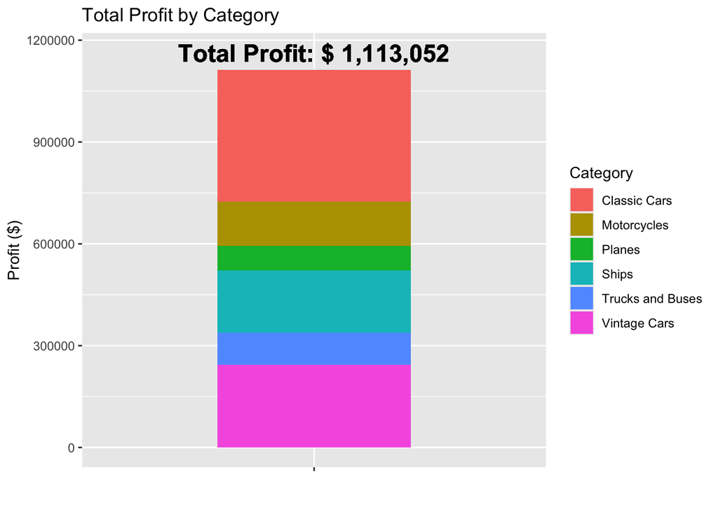

```r
profit_data <- data.frame(
  Category = c("Classic Cars", "Ships", "Motorcycles", "Trucks and Buses", "Planes", "Vintage Cars"),
  Profit = c(388638.825, 185155.313, 130265.169, 93519.924, 71770.8858, 243701.9236)
)

total_profit <- sum(profit_data$Profit)

ggplot(profit_data, aes(x = "", y = Profit, fill = Category)) +
  geom_bar(stat = "identity", width = 0.5) +
  labs(title = "Total Profit by Category",
       y = "Profit ($)",
       x = "") +
  geom_text(aes(x = "", y = total_profit + 50000, label = paste("Total Profit: $", format(total_profit, big.mark = ","))),
            size = 6, fontface = "bold") +
  theme(legend.position = "right")
```

# Multivariate nominal analysis

The following data shows some avenues for further investigations, notably the greater variation in projections between product lines when more factors are accounted for and a more robust regression model is applied

```r
sales <- read.csv("data/sales_data_sample.csv")

sales$order_month = floor_date(as.Date(sales$ORDERDATE, "%m/%d/%Y"), unit="month")
```

Breaking up into product lines, Ships, Vintage Cars, Classic Cars, Planes, Trains, Motorcycles, Trucks and Busses And projecting sales by month, using additive seasonality SHIPS

```r
sales_ships <- sales[sales$PRODUCTLINE == 'Ships',]
monthly_sales_ships <- sales_ships %>%
  group_by(order_month) %>%
  summarise(qty = sum(QUANTITYORDERED))

monthly_sales_ships_ts <- ts(monthly_sales_ships$qty, start=c(2003, 1), frequency=12)
monthly_sales_ships_ts
```

```
##      Jan Feb Mar Apr May Jun Jul Aug Sep Oct Nov Dec
## 2003 301 323 319 318 234 428 921 332 319 244 305 294
## 2004 267 311 286 529 747 303 320 102 545  76 303
```

```r
m_n_a_ships <- ets(monthly_sales_ships_ts, model = "MNA")
m_n_a_ships
```

```
## ETS(M,N,A)
##
## Call:
## ets(y = monthly_sales_ships_ts, model = "MNA")
##
##   Smoothing parameters:
##     alpha = 1e-04
##     gamma = 1e-04
##
##   Initial states:
##     l = 383.0958
##     s = -138.2668 -96.1098 -109.7283 -21.0169 -114.0078 582.7807
##            62.9377 6.0829 -63.6263 26.5056 -38.417 -97.134
##
##   sigma:  0.6182
##
##      AIC     AICc      BIC
## 329.3099 397.8813 346.3423
```

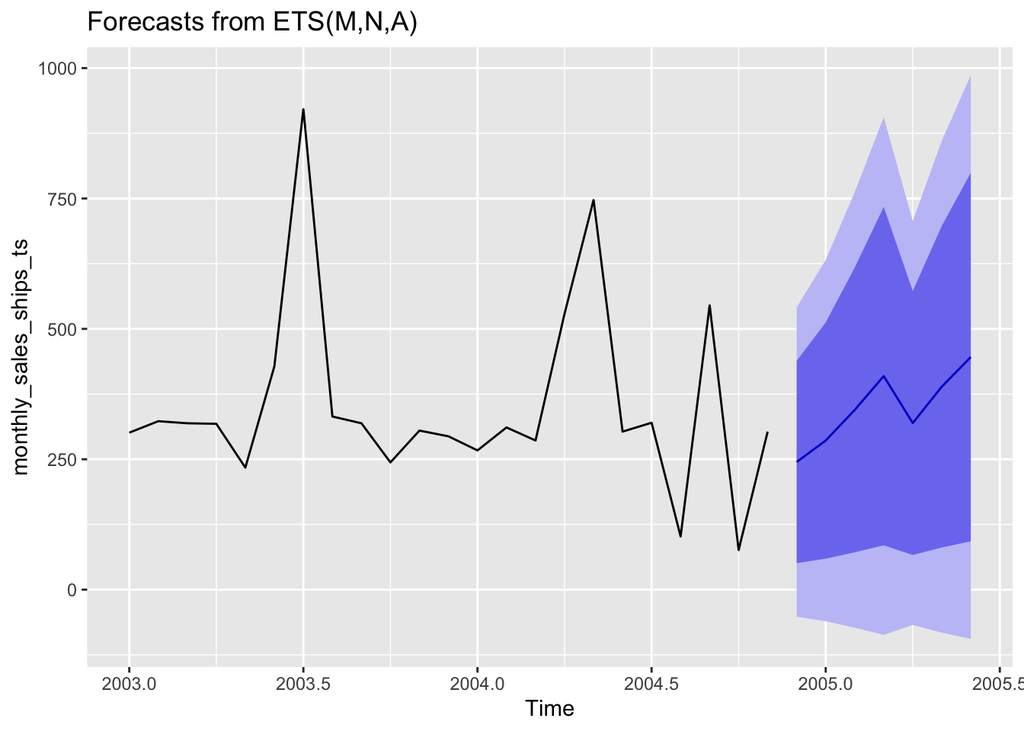

```r
forecast_ships <- forecast(m_n_a_ships, 7)

autoplot(forecast(m_n_a_ships, 7))
```

```r
accuracy(m_n_a_ships)
```

```
##                     ME     RMSE      MAE       MPE     MAPE      MASE      ACF1
## Training set -35.72951 183.1694 115.0138 -30.30332 45.34877 0.5870776 0.1375825
```

```r
forecast_ships
```

```
##          Point Forecast    Lo 80    Hi 80     Lo 95    Hi 95
## Dec 2004       244.7513 50.84333 438.6592 -51.80534 541.3079
## Jan 2005       285.8787 59.38691 512.3705 -60.51059 632.2680
## Feb 2005       344.5906 71.58341 617.5978 -72.93786 762.1190
## Mar 2005       409.4972 85.06677 733.9277 -86.67634 905.6708
## Apr 2005       319.4077 66.35205 572.4634 -67.60753 706.4230
## May 2005       389.1164 80.83296 697.3998 -82.36244 860.5952
## Jun 2005       445.9346 92.63607 799.2332 -94.38888 986.2581
```

VINTAGE CARS

```r
sales_vintage_cars <- sales[sales$PRODUCTLINE == 'Vintage Cars',]
monthly_sales_vintage_cars <- sales_vintage_cars %>%
  group_by(order_month) %>%
  summarise(qty = sum(QUANTITYORDERED))

monthly_sales_vintage_cars_ts <- ts(monthly_sales_vintage_cars$qty, start=c(2003, 1), frequency=12)
monthly_sales_vintage_cars_ts
```

```
##       Jan  Feb  Mar  Apr  May  Jun  Jul  Aug  Sep  Oct  Nov  Dec
## 2003  572  301  563  244  584  313  295  264  587 1115 2130  536
## 2004  843  314  602  618  329  613  481  849  793 1385 2305  818
## 2005  774  776  736  462  867
```

```r
m_n_a_vintage_cars <- ets(monthly_sales_vintage_cars_ts, model = "MNA")
m_n_a_vintage_cars
```

```
## ETS(M,N,A)
##
## Call:
## ets(y = monthly_sales_vintage_cars_ts, model = "MNA")
##
##   Smoothing parameters:
##     alpha = 0.3015
##     gamma = 1e-04
##
##   Initial states:
##     l = 797.6447
##     s = -148.3547 1391.13 475.6428 -78.8604 -153.0277 -369.3302
##            -224.2408 -176.9684 -245.4295 -100.3967 -313.6901 -56.4738
##
##   sigma:  0.3725
##
##      AIC     AICc      BIC
## 425.0043 461.9274 445.5137
```

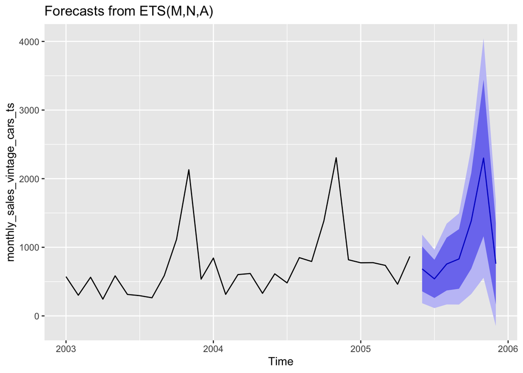

```r
forecast_vintage_cars <- forecast(m_n_a_vintage_cars, 7)

autoplot(forecast(m_n_a_vintage_cars, 7))
```

```r
accuracy(m_n_a_vintage_cars)
```

```
##                    ME     RMSE      MAE       MPE     MAPE      MASE      ACF1
## Training set 12.73345 145.0269 126.2232 -6.838226 25.51328 0.4972873 -0.199222
```

```r
forecast_vintage_cars
```

```
##          Point Forecast     Lo 80     Hi 80     Lo 95     Hi 95
## Jun 2005       684.7568  357.8362 1011.6774  184.7749 1184.7387
## Jul 2005       539.6852  261.3777  817.9927  114.0506  965.3198
## Aug 2005       755.9684  370.8154 1141.1213  166.9278 1345.0090
## Sep 2005       830.1511  395.5496 1264.7525  165.4855 1494.8166
## Oct 2005      1384.6505  687.8912 2081.4098  319.0491 2450.2519
## Nov 2005      2300.1471 1159.8590 3440.4353  556.2269 4044.0674
## Dec 2005       760.6555  167.1359 1354.1751 -147.0544 1668.3654
```

CLASSIC CARS

```r
sales_classic_cars <- sales[sales$PRODUCTLINE == 'Classic Cars',]
monthly_sales_classic_cars <- sales_classic_cars %>%
  group_by(order_month) %>%
  summarise(qty = sum(QUANTITYORDERED))

monthly_sales_classic_cars_ts <- ts(monthly_sales_classic_cars$qty, start=c(2003, 1), frequency=12)
monthly_sales_classic_cars_ts
```

```
##       Jan  Feb  Mar  Apr  May  Jun  Jul  Aug  Sep  Oct  Nov  Dec
## 2003  334  120  929  465  934  338  765  339 1139 2032 3879 1199
## 2004 1073 1114  647  824  610  742 1263 1885  799 1786 3669 1006
## 2005 1333 1352  882 1021 1513
```

```r
m_n_a_classic_cars <- ets(monthly_sales_classic_cars_ts, model = "MNA")
m_n_a_classic_cars
```

```
## ETS(M,N,A)
##
## Call:
## ets(y = monthly_sales_classic_cars_ts, model = "MNA")
##
##   Smoothing parameters:
##     alpha = 0.019
##     gamma = 0.0012
##
##   Initial states:
##     l = 1037.8334
##     s = 167.6502 2910.179 348.5288 0.444 -291.8902 354.1426
##            -466.2467 -44.5966 -391.9533 -166.7434 -599.377 -1820.138
##
##   sigma:  1.2735
##
##      AIC     AICc      BIC
## 521.0491 557.9722 541.5586
```

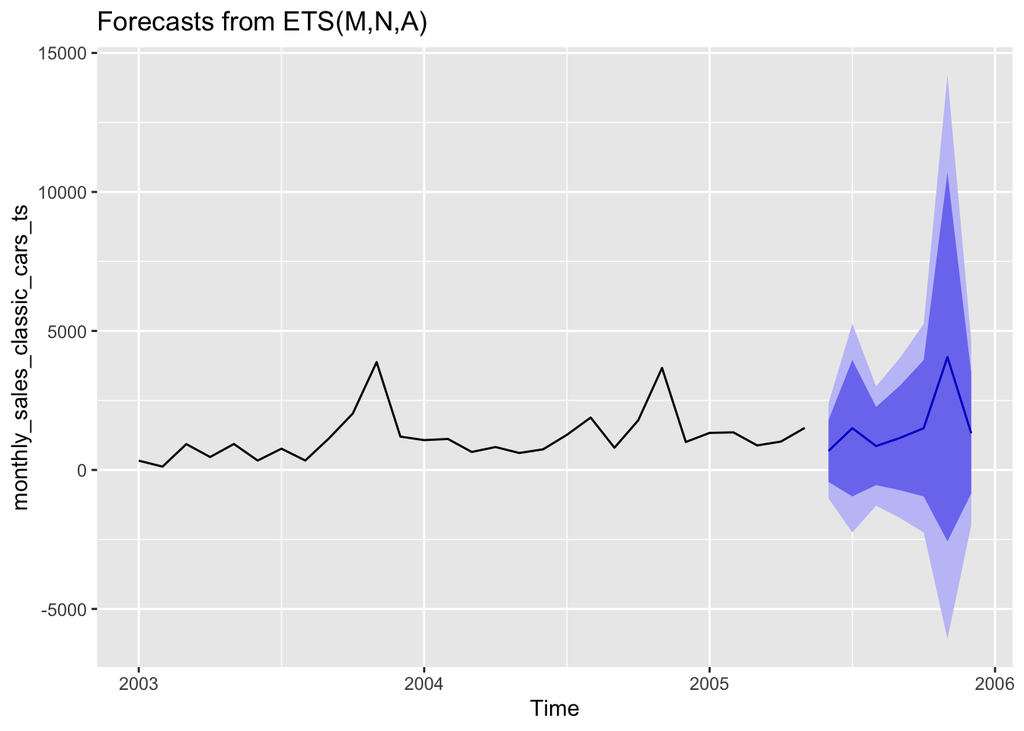

```r
forecast_classic_cars <- forecast(m_n_a_classic_cars, 7)

autoplot(forecast(m_n_a_classic_cars, 7))
```

```r
accuracy(m_n_a_classic_cars)
```

```
##                    ME     RMSE      MAE     MPE     MAPE      MASE       ACF1
## Training set 204.6069 681.2687 466.6736 6.20695 62.41277 0.9956642 0.03809881
```

```r
forecast_classic_cars
```

```
##          Point Forecast      Lo 80     Hi 80     Lo 95     Hi 95
## Jun 2005       684.3422  -432.5751  1801.259 -1023.835  2392.520
## Jul 2005      1503.9218  -950.8754  3958.719 -2250.367  5258.210
## Aug 2005       859.6520  -545.8465  2265.151 -1289.872  3009.176
## Sep 2005      1150.9486  -729.8526  3031.750 -1725.489  4027.386
## Oct 2005      1500.4252  -950.8989  3951.749 -2248.552  5249.402
## Nov 2005      4060.4200 -2567.9504 10688.790 -6076.798 14197.638
## Dec 2005      1318.0666  -846.9423  3483.075 -1993.029  4629.162
```

PLANES

```r
sales_planes <- sales[sales$PRODUCTLINE == 'Planes',]
monthly_sales_planes <- sales_planes %>%
  group_by(order_month) %>%
  summarise(qty = sum(QUANTITYORDERED))

monthly_sales_planes_ts <- ts(monthly_sales_planes$qty, start=c(2003, 1), frequency=12)
monthly_sales_planes_ts
```

```
##       Jan  Feb  Mar  Apr  May  Jun  Jul  Aug  Sep  Oct  Nov  Dec
## 2003  460  401  380  371  725  573   86  413  424  274  424  415
## 2004  434  384  360  390 1325  681  175  270  883  496  383
```

```r
m_n_a_planes <- ets(monthly_sales_planes_ts, model = "MNA")
m_n_a_planes
```

```
## ETS(M,N,A)
##
## Call:
## ets(y = monthly_sales_planes_ts, model = "MNA")
##
##   Smoothing parameters:
##     alpha = 0.1474
##     gamma = 5e-04
##
##   Initial states:
##     l = 405.1247
##     s = -80.7871 -50.9969 -126.1388 76.549 -15.5959 -326.5554
##            72.2382 408.0958 12.3025 10.7376 15.7316 4.4193
##
##   sigma:  0.4055
##
##      AIC     AICc      BIC
## 314.3361 382.9075 331.3685
```

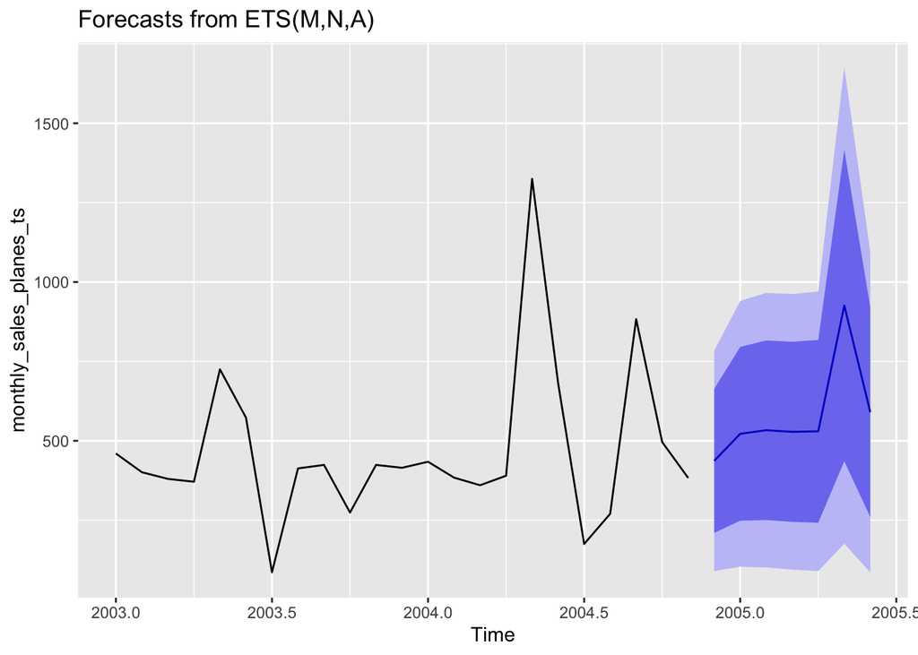

```r
forecast_planes <- forecast(m_n_a_planes, 7)

autoplot(forecast(m_n_a_planes, 7))
```

```r
accuracy(m_n_a_planes)
```

```
##                   ME     RMSE      MAE       MPE     MAPE      MASE        ACF1
## Training set 33.1611 149.8874 94.79602 0.5986878 17.81756 0.5979107 -0.02762412
```

```r
forecast_planes
```

```
##          Point Forecast    Lo 80     Hi 80     Lo 95     Hi 95
## Dec 2004       436.8255 209.8400  663.8110  89.68109  783.9699
## Jan 2005       522.0174 248.3710  795.6637 103.51138  940.5234
## Feb 2005       533.2580 250.5002  816.0158 100.81725  965.6987
## Mar 2005       528.2523 244.5768  811.9277  94.40809  962.0965
## Apr 2005       529.8343 241.9994  817.6692  89.62876  970.0398
## May 2005       925.8876 435.5152 1416.2601 175.92766 1675.8476
## Jun 2005       589.9334 260.0037  919.8631  85.34945 1094.5174
```

TRAINS

```r
sales_trains <- sales[sales$PRODUCTLINE == 'Trains',]
monthly_sales_trains <- sales_trains %>%
  group_by(order_month) %>%
  summarise(qty = sum(QUANTITYORDERED))

monthly_sales_trains_ts <- ts(monthly_sales_trains$qty, start=c(2003, 1), frequency=12)
monthly_sales_trains_ts
```

```
##      Jan Feb Mar Apr May Jun Jul Aug Sep Oct Nov Dec
## 2003  81  38  69 116 106  93 132 320  45  78  73 137
## 2004 131 135 109  88 216 177 159  79 108  99 123
```

```r
m_n_a_trains <- ets(monthly_sales_trains_ts, model = "MNA")
m_n_a_trains
```

```
## ETS(M,N,A)
##
## Call:
## ets(y = monthly_sales_trains_ts, model = "MNA")
##
##   Smoothing parameters:
##     alpha = 1e-04
##     gamma = 1e-04
##
##   Initial states:
##     l = 128.5521
##     s = -2.417 -33.1862 -44.5657 -61.1677 207.809 15.2519
##            -13.66 2.2551 32.9246 -31.5691 -50.1467 -21.5281
##
##   sigma:  0.6087
##
##      AIC     AICc      BIC
## 276.5571 345.1285 293.5895
```

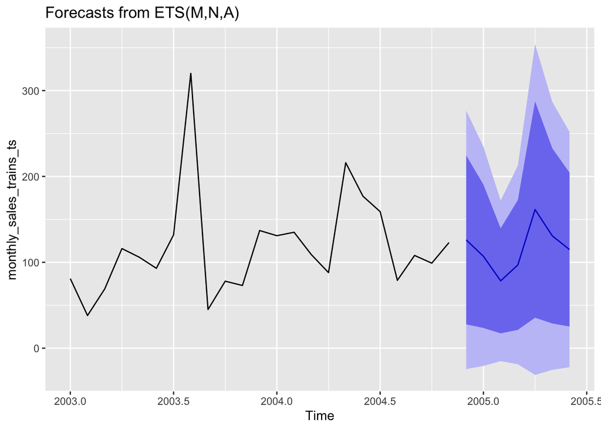

```r
forecast_trains <- forecast(m_n_a_trains, 7)

autoplot(forecast(m_n_a_trains, 7))
```

```r
accuracy(m_n_a_trains)
```

```
##                     ME    RMSE      MAE       MPE     MAPE      MASE
## Training set -10.72514 65.0626 41.11318 -23.37471 44.13128 0.5576388
##                     ACF1
## Training set -0.09254969
```

```r
forecast_trains
```

```
##          Point Forecast    Lo 80    Hi 80     Lo 95    Hi 95
## Dec 2004      126.11146 27.72895 224.4940 -24.35160 276.5745
## Jan 2005      106.99906 23.52658 190.4715 -20.66108 234.6592
## Feb 2005       78.38228 17.23442 139.5301 -15.13530 171.8999
## Mar 2005       96.95671 21.31850 172.5949 -18.72194 212.6354
## Apr 2005      161.44007 35.49688 287.3833 -31.17342 354.0536
## May 2005      130.78858 28.75734 232.8198 -25.25474 286.8319
## Jun 2005      114.87145 25.25753 204.4854 -22.18121 251.9241
```

MOTORCYCLES

```r
sales_motorcycles <- sales[sales$PRODUCTLINE == 'Motorcycles',]
monthly_sales_motorcycles <- sales_motorcycles %>%
  group_by(order_month) %>%
  summarise(qty = sum(QUANTITYORDERED))

monthly_sales_motorcycles_ts <- ts(monthly_sales_motorcycles$qty, start=c(2003, 1), frequency=12)
monthly_sales_motorcycles_ts
```

```
##       Jan  Feb  Mar  Apr  May  Jun  Jul  Aug  Sep  Oct  Nov  Dec
## 2003  229  170  212  251   23  408  440   47  627 1118  214  460
## 2004  493  361  466  493  214  675  430  427 1403  268  377  429
## 2005  513  579  336
```

```r
m_n_a_motorcycles <- ets(monthly_sales_motorcycles_ts, model = "MNA")
m_n_a_motorcycles
```

```
## ETS(M,N,A)
##
## Call:
## ets(y = monthly_sales_motorcycles_ts, model = "MNA")
##
##   Smoothing parameters:
##     alpha = 0.2364
##     gamma = 0.0011
##
##   Initial states:
##     l = 362.4887
##     s = 59.2957 -155.6724 780.0895 236.1309 -259.8077 23.0276
##            52.6282 -319.7247 -121.908 -100.008 -150.8804 -43.1707
##
##   sigma:  0.5904
##
##      AIC     AICc      BIC
## 382.4029 426.0392 401.8404
```

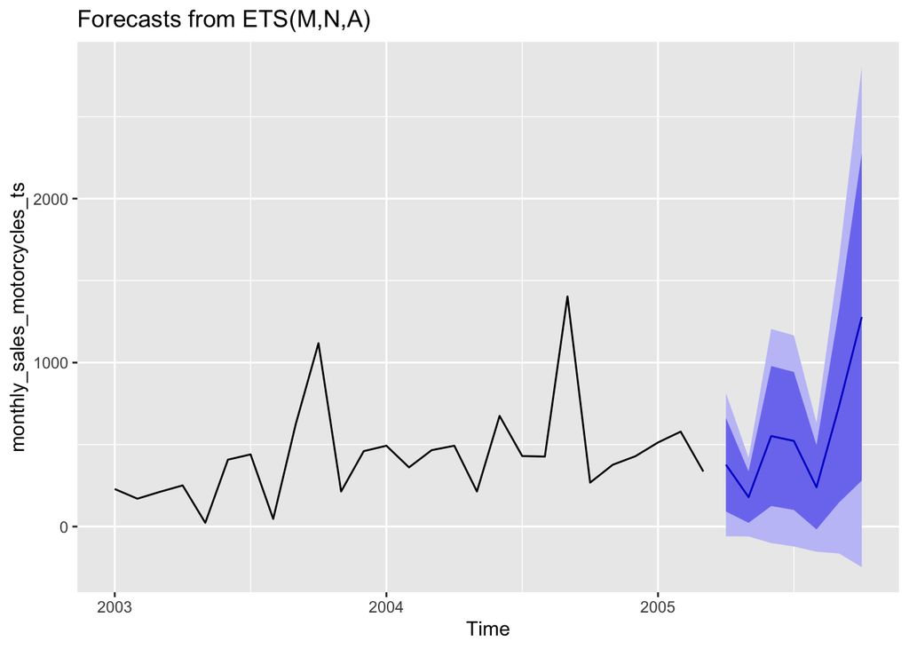

```r
forecast_motorcycles <- forecast(m_n_a_motorcycles, 7)

autoplot(forecast(m_n_a_motorcycles, 7))
```

```r
accuracy(m_n_a_motorcycles)
```

```
##                   ME     RMSE    MAE       MPE     MAPE      MASE       ACF1
## Training set 21.4346 280.6644 147.06 -10.48907 41.49249 0.5532731 -0.3677267
```

```r
forecast_motorcycles
```

```
##          Point Forecast     Lo 80     Hi 80      Lo 95     Hi 95
## Apr 2005       377.6103  91.89493  663.3257  -59.35365  814.5743
## May 2005       179.6239  22.70102  336.5467  -60.36892  419.6167
## Jun 2005       552.0770 125.27661  978.8773 -100.65784 1204.8117
## Jul 2005       522.2772 101.40770  943.1467 -121.38716 1165.9416
## Aug 2005       239.6395 -17.31080  496.5897 -153.33205  632.6110
## Sep 2005       736.1549 147.49166 1324.8182 -164.12785 1636.4377
## Oct 2005      1278.0734 280.30935 2275.8374 -247.87502 2804.0217
```

TRUCKS AND BUSES

```r
sales_trucks_and_buses <- sales[sales$PRODUCTLINE == 'Trucks and Buses',]
monthly_sales_trucks_and_buses <- sales_trucks_and_buses %>%
  group_by(order_month) %>%
  summarise(qty = sum(QUANTITYORDERED))

monthly_sales_trucks_and_buses_ts <- ts(monthly_sales_trucks_and_buses$qty, start=c(2003, 1), frequency=12)
monthly_sales_trucks_and_buses_ts
```

```
##       Jan  Feb  Mar  Apr  May  Jun  Jul  Aug  Sep  Oct  Nov  Dec
## 2003  370   93  279  248  160  257  136  410  456 1238  409   46
## 2004  324  348  353  414  380  351  415  750 1052  569  337  356
## 2005  194  832
```

```r
m_n_a_trucks_and_buses <- ets(monthly_sales_trucks_and_buses_ts, model = "MNA")
m_n_a_trucks_and_buses
```

```
## ETS(M,N,A)
##
## Call:
## ets(y = monthly_sales_trucks_and_buses_ts, model = "MNA")
##
##   Smoothing parameters:
##     alpha = 0.1717
##     gamma = 2e-04
##
##   Initial states:
##     l = 312.951
##     s = -251.8346 -1.0242 815.8651 62.9874 94.3886 -232.4891
##            -66.8496 -169.4372 -42.402 16.008 -128.9333 -96.2791
##
##   sigma:  0.9366
##
##      AIC     AICc      BIC
## 387.7906 435.7906 406.6621
```

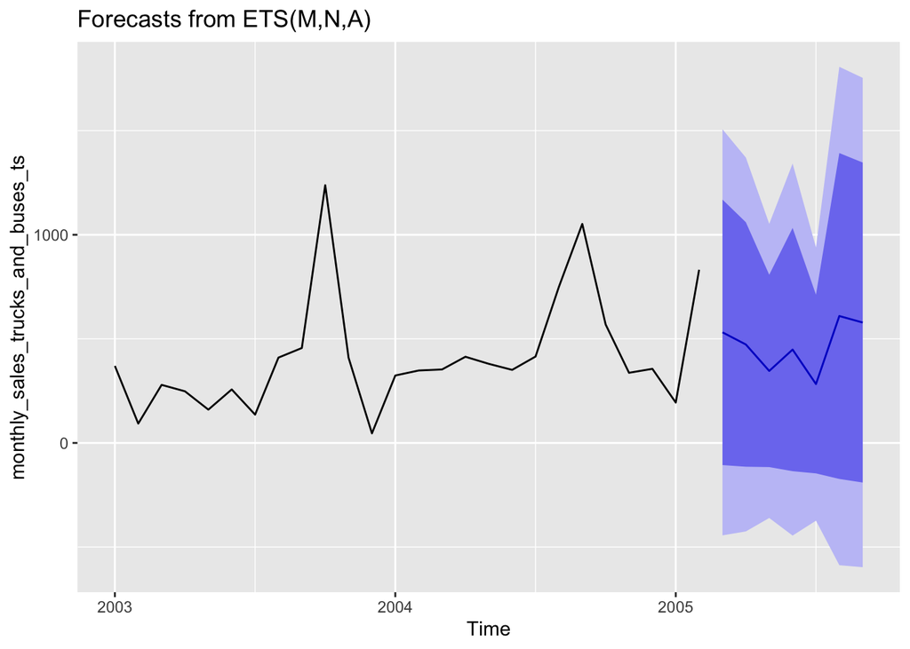

```r
forecast_trucks_and_buses <- forecast(m_n_a_trucks_and_buses, 7)

autoplot(forecast(m_n_a_trucks_and_buses, 7))
```

```r
accuracy(m_n_a_trucks_and_buses)
```

```
##                    ME     RMSE      MAE       MPE    MAPE      MASE       ACF1
## Training set 45.33532 240.0825 151.7489 -1.920288 40.9316 0.5688043 -0.2331817
```

```r
forecast_trucks_and_buses
```

```
##          Point Forecast     Lo 80     Hi 80     Lo 95     Hi 95
## Mar 2005       531.3160 -106.4142 1169.0462 -444.0082 1506.6402
## Apr 2005       472.9312 -114.2084 1060.0709 -425.0214 1370.8838
## May 2005       345.9145 -115.9338  807.7629 -360.4216 1052.2507
## Jun 2005       448.4763 -135.7147 1032.6672 -444.9667 1341.9192
## Jul 2005       282.8784 -146.2635  712.0204 -373.4376  939.1945
## Aug 2005       609.7417 -172.9863 1392.4697 -587.3375 1806.8209
## Sep 2005       578.3985 -190.1340 1346.9309 -596.9705 1753.7674
```

```r
summary_forecast <- print(forecast_ships)
```

```
##          Point Forecast    Lo 80    Hi 80     Lo 95    Hi 95
## Dec 2004       244.7513 50.84333 438.6592 -51.80534 541.3079
## Jan 2005       285.8787 59.38691 512.3705 -60.51059 632.2680
## Feb 2005       344.5906 71.58341 617.5978 -72.93786 762.1190
## Mar 2005       409.4972 85.06677 733.9277 -86.67634 905.6708
## Apr 2005       319.4077 66.35205 572.4634 -67.60753 706.4230
## May 2005       389.1164 80.83296 697.3998 -82.36244 860.5952
## Jun 2005       445.9346 92.63607 799.2332 -94.38888 986.2581
```

```r
summary_forecast$`Point Forecast` <- summary_forecast$`Lo 80` <- summary_forecast$`Hi 80` <- summary_forecast$`Lo 95` <- summary_forecast$`Hi 95` <- NULL
summary_forecast$ships <- print(forecast_ships)[, 1]
```

```
##          Point Forecast    Lo 80    Hi 80     Lo 95    Hi 95
## Dec 2004       244.7513 50.84333 438.6592 -51.80534 541.3079
## Jan 2005       285.8787 59.38691 512.3705 -60.51059 632.2680
## Feb 2005       344.5906 71.58341 617.5978 -72.93786 762.1190
## Mar 2005       409.4972 85.06677 733.9277 -86.67634 905.6708
## Apr 2005       319.4077 66.35205 572.4634 -67.60753 706.4230
## May 2005       389.1164 80.83296 697.3998 -82.36244 860.5952
## Jun 2005       445.9346 92.63607 799.2332 -94.38888 986.2581
```

```r
summary_forecast$trucks_and_buses <- print(forecast_trucks_and_buses)[, 1]
```

```
##          Point Forecast     Lo 80     Hi 80     Lo 95     Hi 95
## Mar 2005       531.3160 -106.4142 1169.0462 -444.0082 1506.6402
## Apr 2005       472.9312 -114.2084 1060.0709 -425.0214 1370.8838
## May 2005       345.9145 -115.9338  807.7629 -360.4216 1052.2507
## Jun 2005       448.4763 -135.7147 1032.6672 -444.9667 1341.9192
## Jul 2005       282.8784 -146.2635  712.0204 -373.4376  939.1945
## Aug 2005       609.7417 -172.9863 1392.4697 -587.3375 1806.8209
## Sep 2005       578.3985 -190.1340 1346.9309 -596.9705 1753.7674
```

```r
summary_forecast$vintage_cars <- print(forecast_vintage_cars)[, 1]
```

```
##          Point Forecast     Lo 80     Hi 80     Lo 95     Hi 95
## Jun 2005       684.7568  357.8362 1011.6774  184.7749 1184.7387
## Jul 2005       539.6852  261.3777  817.9927  114.0506  965.3198
## Aug 2005       755.9684  370.8154 1141.1213  166.9278 1345.0090
## Sep 2005       830.1511  395.5496 1264.7525  165.4855 1494.8166
## Oct 2005      1384.6505  687.8912 2081.4098  319.0491 2450.2519
## Nov 2005      2300.1471 1159.8590 3440.4353  556.2269 4044.0674
## Dec 2005       760.6555  167.1359 1354.1751 -147.0544 1668.3654
```

```r
summary_forecast$classic_cars <- print(forecast_classic_cars)[, 1]
```

```
##          Point Forecast      Lo 80     Hi 80     Lo 95     Hi 95
## Jun 2005       684.3422  -432.5751  1801.259 -1023.835  2392.520
## Jul 2005      1503.9218  -950.8754  3958.719 -2250.367  5258.210
## Aug 2005       859.6520  -545.8465  2265.151 -1289.872  3009.176
## Sep 2005      1150.9486  -729.8526  3031.750 -1725.489  4027.386
## Oct 2005      1500.4252  -950.8989  3951.749 -2248.552  5249.402
## Nov 2005      4060.4200 -2567.9504 10688.790 -6076.798 14197.638
## Dec 2005      1318.0666  -846.9423  3483.075 -1993.029  4629.162
```

```r
summary_forecast$planes <- print(forecast_planes)[, 1]
```

```
##          Point Forecast    Lo 80     Hi 80     Lo 95     Hi 95
## Dec 2004       436.8255 209.8400  663.8110  89.68109  783.9699
## Jan 2005       522.0174 248.3710  795.6637 103.51138  940.5234
## Feb 2005       533.2580 250.5002  816.0158 100.81725  965.6987
## Mar 2005       528.2523 244.5768  811.9277  94.40809  962.0965
## Apr 2005       529.8343 241.9994  817.6692  89.62876  970.0398
## May 2005       925.8876 435.5152 1416.2601 175.92766 1675.8476
## Jun 2005       589.9334 260.0037  919.8631  85.34945 1094.5174
```

```r
summary_forecast$trains <- print(forecast_trains)[, 1]
```

```
##          Point Forecast    Lo 80    Hi 80     Lo 95    Hi 95
## Dec 2004      126.11146 27.72895 224.4940 -24.35160 276.5745
## Jan 2005      106.99906 23.52658 190.4715 -20.66108 234.6592
## Feb 2005       78.38228 17.23442 139.5301 -15.13530 171.8999
## Mar 2005       96.95671 21.31850 172.5949 -18.72194 212.6354
## Apr 2005      161.44007 35.49688 287.3833 -31.17342 354.0536
## May 2005      130.78858 28.75734 232.8198 -25.25474 286.8319
## Jun 2005      114.87145 25.25753 204.4854 -22.18121 251.9241
```

```r
summary_forecast$motorcycles <- print(forecast_motorcycles)[, 1]
```

```
##          Point Forecast     Lo 80     Hi 80      Lo 95     Hi 95
## Apr 2005       377.6103  91.89493  663.3257  -59.35365  814.5743
## May 2005       179.6239  22.70102  336.5467  -60.36892  419.6167
## Jun 2005       552.0770 125.27661  978.8773 -100.65784 1204.8117
## Jul 2005       522.2772 101.40770  943.1467 -121.38716 1165.9416
## Aug 2005       239.6395 -17.31080  496.5897 -153.33205  632.6110
## Sep 2005       736.1549 147.49166 1324.8182 -164.12785 1636.4377
## Oct 2005      1278.0734 280.30935 2275.8374 -247.87502 2804.0217
```

```r
summary_forecast
```

```
##             ships trucks_and_buses vintage_cars classic_cars   planes    trains
## Dec 2004 244.7513         531.3160     684.7568     684.3422 436.8255 126.11146
## Jan 2005 285.8787         472.9312     539.6852    1503.9218 522.0174 106.99906
## Feb 2005 344.5906         345.9145     755.9684     859.6520 533.2580  78.38228
## Mar 2005 409.4972         448.4763     830.1511    1150.9486 528.2523  96.95671
## Apr 2005 319.4077         282.8784    1384.6505    1500.4252 529.8343 161.44007
## May 2005 389.1164         609.7417    2300.1471    4060.4200 925.8876 130.78858
## Jun 2005 445.9346         578.3985     760.6555    1318.0666 589.9334 114.87145
##          motorcycles
## Dec 2004    377.6103
## Jan 2005    179.6239
## Feb 2005    552.0770
## Mar 2005    522.2772
## Apr 2005    239.6395
## May 2005    736.1549
## Jun 2005   1278.0734
```